# Project 2: Analysis of Titanic Dataset

The sinking of the RMS Titanic is one of the most infamous shipwrecks in history. On April 15, 1912, during her maiden voyage, the Titanic sank after colliding with an iceberg, killing 1502 out of 2224 passengers and crew.

This dataset contains demographics and passenger information from 891 of the 2224 passengers and crew on board the Titanic.

This report will analyze the data set and try to answer the following questions: What factors made the people more likely to survive? Did being male or female help to survive? Was it being in 1st class? Did age play a factor?

```python
%matplotlib inline
import matplotlib.pyplot as plt
import numpy as np
import pandas as pd

titanic_df = pd.read_csv('titanic-data.csv')
```

**Information about the data:**

After reading in the dataset, print out some information to understand the data.

```python
# First get the number of rows and columns
titanic_df.shape
```

```
(891, 12)
```

```python
#print few rows
titanic_df.head()
```

|  | PassengerId | Survived | Pclass | Name | Sex | Age | SibSp | Parch | Ticket | Fare | Cabin | Embarked |
| --- | --- | --- | --- | --- | --- | --- | --- | --- | --- | --- | --- | --- |
| 0 | 1 | 0 | 3 | Braund, Mr. Owen Harris | male | 22.0 | 1 | 0 | A/5 21171 | 7.2500 | NaN | S |
| 1 | 2 | 1 | 1 | Cumings, Mrs. John Bradley (Florence Briggs Th... | female | 38.0 | 1 | 0 | PC 17599 | 71.2833 | C85 | C |
| 2 | 3 | 1 | 3 | Heikkinen, Miss. Laina | female | 26.0 | 0 | 0 | STON/O2. 3101282 | 7.9250 | NaN | S |
| 3 | 4 | 1 | 1 | Futrelle, Mrs. Jacques Heath (Lily May Peel) | female | 35.0 | 1 | 0 | 113803 | 53.1000 | C123 | S |
| 4 | 5 | 0 | 3 | Allen, Mr. William Henry | male | 35.0 | 0 | 0 | 373450 | 8.0500 | NaN | S |

```python
#And find out the types of each column
titanic_df.dtypes
```

```
PassengerId      int64
Survived         int64
Pclass           int64
Name            object
Sex             object
Age            float64
SibSp            int64
Parch            int64
Ticket          object
Fare           float64
Cabin           object
Embarked        object
dtype: object
```

```python
# Get the summary statistics
titanic_df.describe(include='all')
```

|  | PassengerId | Survived | Pclass | Name | Sex | Age | SibSp | Parch | Ticket | Fare | Cabin | Embarked |
| --- | --- | --- | --- | --- | --- | --- | --- | --- | --- | --- | --- | --- |
| count | 891.000000 | 891.000000 | 891.000000 | 891 | 891 | 714.000000 | 891.000000 | 891.000000 | 891 | 891.000000 | 204 | 889 |
| unique | NaN | NaN | NaN | 891 | 2 | NaN | NaN | NaN | 681 | NaN | 147 | 3 |
| top | NaN | NaN | NaN | Clifford, Mr. George Quincy | male | NaN | NaN | NaN | 1601 | NaN | B96 B98 | S |
| freq | NaN | NaN | NaN | 1 | 577 | NaN | NaN | NaN | 7 | NaN | 4 | 644 |
| mean | 446.000000 | 0.383838 | 2.308642 | NaN | NaN | 29.699118 | 0.523008 | 0.381594 | NaN | 32.204208 | NaN | NaN |
| std | 257.353842 | 0.486592 | 0.836071 | NaN | NaN | 14.526497 | 1.102743 | 0.806057 | NaN | 49.693429 | NaN | NaN |
| min | 1.000000 | 0.000000 | 1.000000 | NaN | NaN | 0.420000 | 0.000000 | 0.000000 | NaN | 0.000000 | NaN | NaN |
| 25% | 223.500000 | 0.000000 | 2.000000 | NaN | NaN | 20.125000 | 0.000000 | 0.000000 | NaN | 7.910400 | NaN | NaN |
| 50% | 446.000000 | 0.000000 | 3.000000 | NaN | NaN | 28.000000 | 0.000000 | 0.000000 | NaN | 14.454200 | NaN | NaN |
| 75% | 668.500000 | 1.000000 | 3.000000 | NaN | NaN | 38.000000 | 1.000000 | 0.000000 | NaN | 31.000000 | NaN | NaN |
| max | 891.000000 | 1.000000 | 3.000000 | NaN | NaN | 80.000000 | 8.000000 | 6.000000 | NaN | 512.329200 | NaN | NaN |

```python
print (titanic_df.isnull().sum())
```

```
PassengerId      0
Survived         0
Pclass           0
Name             0
Sex              0
Age            177
SibSp            0
Parch            0
Ticket           0
Fare             0
Cabin          687
Embarked         2
dtype: int64
```

**Missing Data:**

We see from the above statistics (count) that the 'Age' column has 177 (891 - 714) missing values, 'Cabin' column has 687 (891 - 204) missing values and 'Embarked' has 2 (891 - 889) missing values. The missing data can be dropped, or imputed like replacing with mean/median of the column. I decided to drop the missing data.

**Analysis:**

First, I will find how many passengers survived the shipwreck.

```python
#Out of a total of 891 passengers how many survived and how many died?
print ('Total number of passengers on the Titanic: 891')
print ('Number of passengers who survived: ', (titanic_df['Survived'] == 1).sum())
print ('Number of passengers who died: ',(titanic_df['Survived'] == 0).sum())
```

```
Total number of passengers on the Titanic: 891
Number of passengers who survived:  342
Number of passengers who died:  549
```

Total number of passengers: 891

Number who survived: 342

Number who died: 549

Less than half of the passengers survived. I will use a stacked bar plot to observe it visually.

```
Survived/Not
Not Survived    549
Survived        342
dtype: int64
```

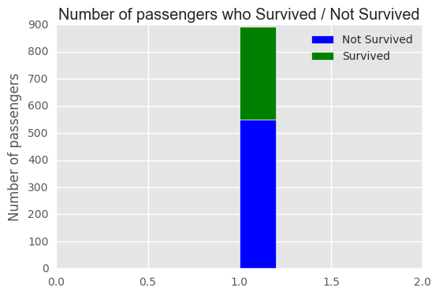

```python
# plot of number who survived and number that did not survive

df1 = pd.DataFrame()
df1['Survived/Not'] = titanic_df['Survived'].apply(lambda x: 'Survived' if x == 1 else 'Not Survived')
grouped_val = df1.groupby('Survived/Not').size()
print (grouped_val)
x = grouped_val[0]
y = grouped_val[1]

fig = plt.figure()
ax = fig.add_subplot(1,1,1)
ax.set_xlim(0, 2)
plt.bar(1,x,color='b',width=0.2,label='Not Survived')
plt.bar(1,y,color='g',bottom=x,width=0.2,label='Survived')
plt.ylabel("Number of passengers")
#plt.xlabel("Width of the bar")
plt.title("Number of passengers who Survived / Not Survived")
plt.legend()
plt.show()
```

This stacked bar chart shows the number of passengers who survived and the number who did not survive.

```
The median age:  28.0
The mean age:  29.69911764705882
```

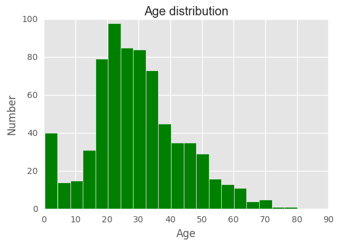

```python
# plot a histogram showing the age distribution of the passengers
print ('The median age: ',titanic_df['Age'].median())
print ('The mean age: ',titanic_df['Age'].mean())
fig=plt.figure()
ax = fig.add_subplot(1,1,1)
titanic_df['Age'].dropna(inplace=True)
ax.hist(titanic_df.Age,bins = 20,color='g')
plt.title('Age distribution')
plt.ylabel('Number')
plt.xlabel('Age')
plt.show()
```

This histogram plot shows that most of the passengers were likely between 20 and 35 years old with the range of ages being between a few months to 80 years. The median of the ages was 28 years and the mean 29.69 years. Knowing the range of ages of the passengers, I will next check if more young people survived the wreck or was it older passengers.

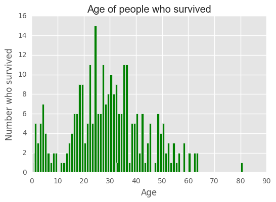

```python
# plot to find whether being younger or older helped to survive
var1 = titanic_df.groupby('Age').Survived.sum().reset_index()
fig = plt.figure()
ax = fig.add_subplot(1,1,1)
ax.set_xlabel('Age')
ax.set_ylabel('Number who survived')
ax.set_title("Age of people who survived")
y_axis = var1.Survived
x_axis = var1.Age
width_n = .8
bar_color = 'green'
plt.bar(x_axis, y_axis, width=width_n, color=bar_color)
plt.show()
```

This plot shows that survival was higher among passengers who were between 25 and 35 years old. The 'Age' column of the dataset had 177 missing values so the result could be skewed. This same information is shown in the following violin plot.

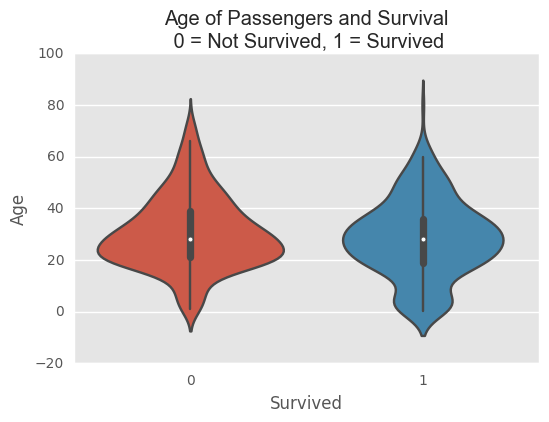

```python
age_plot = sns.violinplot(x=titanic_df.Survived,y=titanic_df.Age)
age_plot.set(title = 'Age of Passengers and Survival\n 0 = Not Survived, 1 = Survived')
```

More younger passengers seem to have survived than older passengers. Among the passengers who survived were there more females or males?

```
Numer of Females who survived:  233
Number of Females who died:  81
Number of Males who survived:  109
Number of Males who died:  468
```

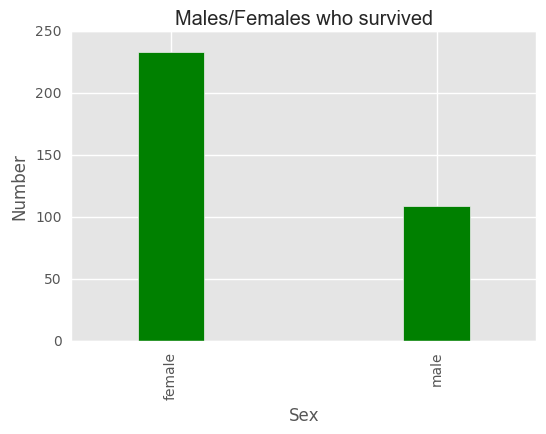

```python
# find if gender played a role in survival
print ('Numer of Females who survived: ',((titanic_df['Survived'] == 1) & (titanic_df['Sex'] == 'female')).sum())
print ('Number of Females who died: ',((titanic_df['Survived'] == 0) & (titanic_df['Sex'] == 'female')).sum())
print ('Number of Males who survived: ',((titanic_df['Survived'] == 1) & (titanic_df['Sex'] == 'male')).sum())
print ('Number of Males who died: ',((titanic_df['Survived'] == 0) & (titanic_df['Sex'] == 'male')).sum())
var = titanic_df.groupby('Sex').Survived.sum()
fig = plt.figure()
ax = fig.add_subplot(1,1,1)
ax.set_xlabel('Sex')
ax.set_ylabel('Number')
ax.set_title("Males/Females who survived")
var.plot(kind='bar',color='g',width=0.25)
```

The above bar plot shows the number of females and males who survived the shipwreck. There were 233 females and 109 males who survived out of a total of 891 passengers. This same information can be seen below in a violin plot.

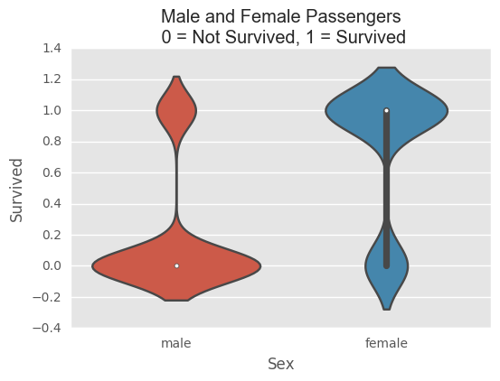

```python
import seaborn as sns
gender_plot = sns.violinplot(x=titanic_df.Sex,y=titanic_df.Survived)
gender_plot.set(title = 'Male and Female Passengers\n 0 = Not Survived, 1 = Survived')
```

The above violin plot shows that more females survived than males. Let's use a statistical test to verify this. The test I will use is Chi-square for independence since the data is categorical and based on frequency/count.

The null hypothesis is that survival is independent of gender. The alternate hypothesis is that there is an association between gender and survival. Conditions for Chi-square are met:

1. The data is frequency/count
2. The expected counts are greater than 5
3. The dataset is assumed to be population.

```python
#Chi square statistical test
import scipy.stats as sp
freq_table = pd.crosstab(titanic_df['Survived'],titanic_df['Sex'])
print ('Frequency Table')
print (freq_table)
chisq,pval,dof,exp = sp.chi2_contingency(freq_table)
print ('Chi square: ',chisq)
print ('pval: ',pval)
```

```
Frequency Table
Sex       female  male
Survived
0             81   468
1            233   109
Chi square:  260.717020167
pval:  1.19735706278e-58
```

Since the p-value is very small the test is statistically significant. Hence we reject the null hypothesis and retain the alternate. There is a strong evidence that there is an association between gender and survival. Females were more likely to survive than males.

The next factor to check is if having siblings/spouse helped to increase the odds of survival.

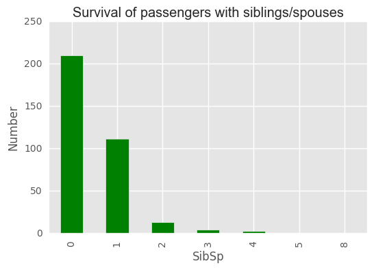

```python
# did having a sibling or a spouse help survival
titanic_df['SibSp'].dropna(inplace=True)
var = titanic_df.groupby('SibSp').Survived.sum()
fig = plt.figure()
ax = fig.add_subplot(1,1,1)
ax.set_xlabel('Siblings/Spouse')
ax.set_ylabel('Number')
ax.set_title("Survival of passengers with siblings/spouses")
var.plot(kind='bar',color='g')
```

This plot shows that there were more passengers with no siblings/spouses who survived than passengers with siblings/spouse.

Similarly, I will check if having parents or children helped to increase the survival.

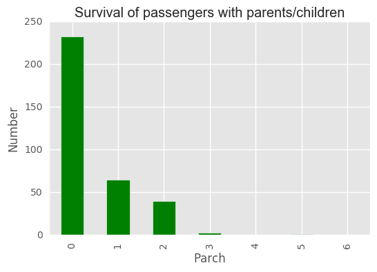

```python
# survival of passengers with parents/children
titanic_df['Parch'].dropna(inplace=True)
var = titanic_df.groupby('Parch').Survived.sum()
fig = plt.figure()
ax = fig.add_subplot(1,1,1)
ax.set_xlabel('Parents/Children')
ax.set_ylabel('Number')
ax.set_title("Survival of passengers with parents/children")
var.plot(kind='bar',color='g')
```

This bar plot shows that more passengers survived who had no parents or children than passengers who had parents and children aboard the ship.

There were three classes (first, second and third) on the ship. Did more passengers who were in first class survive or was it second or third class?

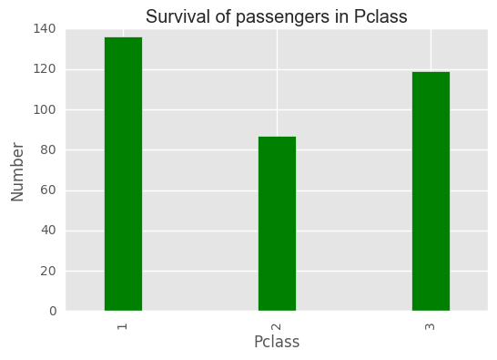

```python
# plot to show which passenger class was important in survival
titanic_df['Pclass'].dropna(inplace=True)
var = titanic_df.groupby('Pclass').Survived.sum()
fig = plt.figure()
ax = fig.add_subplot(1,1,1)
ax.set_xlabel('Passenger Class')
ax.set_ylabel('Number')
ax.set_title("Survival of passengers in Pclass")
var.plot(kind='bar',color='g',width=0.25)
```

Let's use a statistical test to verify this. The test I will use is Chi-square test for independence since the data is categorical and based on frequency/count.

The null hypothesis is that survival is independent of passenger class. The alternate hypothesis is that there is an association between passenger class and survival.

Conditions for Chi-square testing are met:

The data is frequency/count.

The expected counts are greater than 5.

The dataset is assumed to be population.

```python
freq_table = pd.crosstab(titanic_df['Survived'],titanic_df['Pclass'])
print ('Frequency Table')
print (freq_table)
chisq,pval,dof,exp = sp.chi2_contingency(freq_table)
print ('Chi square: ',chisq)
print ('pval: ',pval)
```

```
Frequency Table
Pclass      1   2    3
Survived
0          80  97  372
1         136  87  119
Chi square:  102.888988757
pval:  4.5492517113e-23
```

Passengers seem to have paid a range of fares for the voyage, from a few pounds to more than 500. Now did that play a part in their survival?

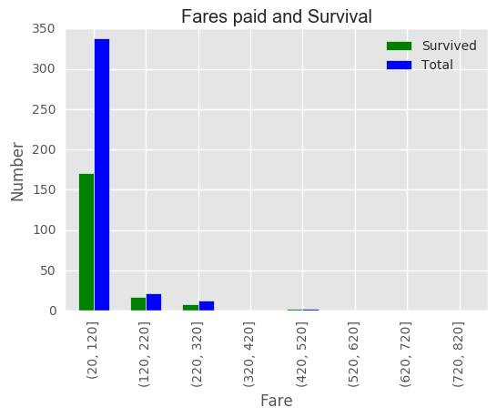

```python
# fares paid and survival rate
new_df = pd.DataFrame()
fares_df = titanic_df['Fare']
group_by_fares = pd.cut(fares_df,np.arange(20,900,100))
var_sur = titanic_df.groupby(group_by_fares).Survived.sum()
var_total = titanic_df.groupby(group_by_fares).Survived.count()
new_df['Survived'] = var_sur
new_df['Total'] = var_total
new_df.plot(kind='bar',width=0.6,color=['green','blue'])
plt.title('Fares paid and Survival')
plt.ylabel('Number')
plt.legend()
plt.show()
```

Most of passengers seem to have paid low fare. That is probably the reason that the graph is showing higher survival for low fare.

Lastly, did the ports where the passengers embarked from, play a part in their survival?

```
Total passengers from Cherbough:  168
And the number from Cherbough who survived:  93
Total passengers from Queenstown:  77
And the number from Queenstown who survived:  30
Total passengers from Southampton:  644
And the number from Southampton who survived:  217
```

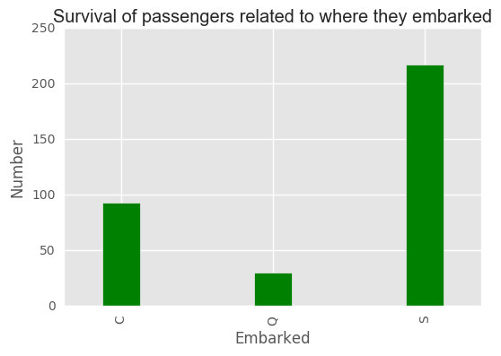

```python
# embarkation and survival rate
titanic_df['Embarked'].dropna(inplace=True)
print ('Total passengers from Cherbough: ',(titanic_df['Embarked'] == 'C').sum())
print ('And the number from Cherbough who survived: ',((titanic_df['Embarked'] == 'C') & (titanic_df['Survived'] == 1)).sum())
print ('Total passengers from Queenstown: ',(titanic_df['Embarked'] == 'Q').sum())
print ('And the number from Queenstown who survived: ',((titanic_df['Embarked'] == 'Q') & (titanic_df['Survived'] == 1)).sum())
print ('Total passengers from Southampton: ',(titanic_df['Embarked'] == 'S').sum())
print ('And the number from Southampton who survived: ',((titanic_df['Embarked'] == 'S') & (titanic_df['Survived'] == 1)).sum())

var = titanic_df.groupby('Embarked').Survived.sum()
fig = plt.figure()
ax = fig.add_subplot(1,1,1)
ax.set_xlabel('Embarked')
ax.set_ylabel('Number')
ax.set_title("Survival of passengers related to where they embarked")
var.plot(kind='bar',color='g',width=0.25)
```

The plot shows that passengers who embarked from Southampton had higher survival. This is probably because most of the passengers (644 out of 891) were from Southampton.

There were 177 missing values in the 'Age' column and 687 missing values in 'Cabin' column and 2 values missing in 'Embarked' column. The missing values were dropped for analysis. This could skew the results.

PassengerId, Cabin, Ticket and Name columns were excluded from the analysis since these columns did not seem to have had an impact on survival.

**Conclusions:**

These conclusions are based on the given dataset (891 out of 2224 total passengers) and could be skewed.

Statistical tests were done to verify that survival was greater for females and also for first class passengers.

**References:**

1. https://plot.ly/pandas/bar-charts/
2. https://www.analyticsvidhya.com
3. http://onlinestatbook.com/2/chi_square/Chi_Square.html
4. http://pandas.pydata.org/pandas-docs/version/0.18.1/visualization.html